# README

Aleksandra Lubicka, Rafał Kaczmarek

# Introduction

The purpose of this paper is to replicate the study described in the paper titled [‘A Machine Learning-Based Approach for Spatial Estimation Using the Spatial Features of Coordinate Information’](https://www.mdpi.com/2220-9964/9/10/587). The authors of the study compare two spatial data modeling methods and they are kriging and spatial machine learning. This article was selected because it presents a very interesting area of analysis and its replication is possible using data available for Poland.

**Stages of analysis:**

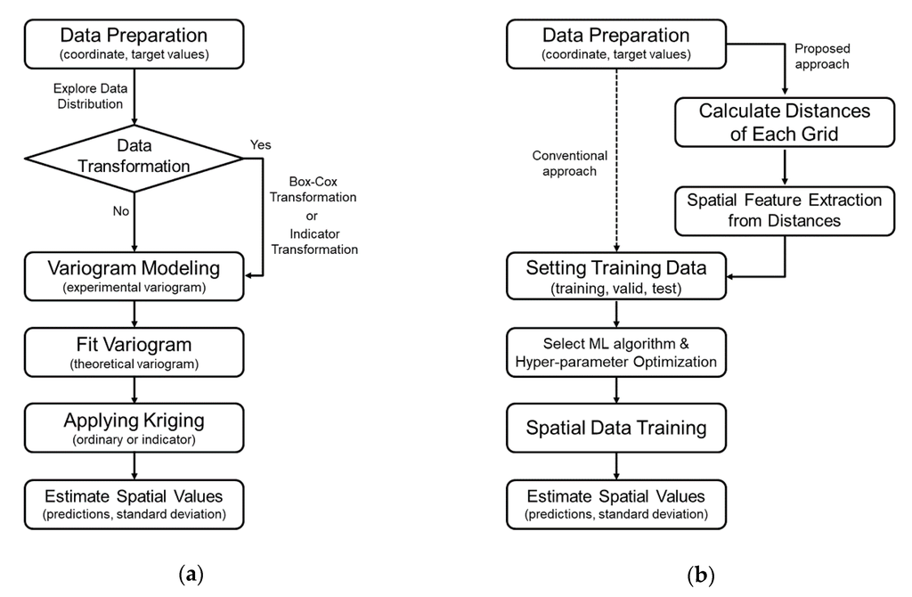

1.Preparation of spatial data.

2.Preparing a kriging model in R.

3.Preparing a spatial machine learning model in python.

4.Comparison of the results obtained between the different models.

5.Summary of findings and comparison of results with those obtained in the original study using R markdown.

# Data

The data used for the study is also spatial character, but it covers a different area. The use of the spatial models described in the paper for the location data of **gas stations in Warsaw** will be investigated. Data was collected on *station address, geographic coordinates, average traffic per week, and number of customers by time of day and day of week*. The **Open Street Maps** API was connected to calculate the density of stations in the vicinity of the point, the distance to neighboring units, the distance to the center, and major access roads, which allowed the distance to be determined based on the distance a car must travel when driving on the nearest possible road. Data on the size of the population in Warsaw was also used for the study. In addition, the variables characterizing each outlet were fuel price, opening hours, and average rating given by consumers.

## Hypotheses

We expect that the extracted **spatial features improve the performance of MLA for spatial estimation** because they have characteristics of spatial correlation represented by distances. To verify the proposed approach, indicator **Kriging was used as a benchmark model**, and each performance of MLA was compared when using raw coordinates, distance vector, and spatial features extracted from distance vector as inputs. Thus, it is one thing **to improve estimation performance by including spatial variables**, and another to say that **spatial machine learning models produce more accurate estimates than basic spatial models**.

## Research metods

The paper mainly describes two research methods:

### Kriging

Among the geostatistical techniques for spatial estimation, indicator Kriging is a non-parametric approach that can be applied when the sample dataset is skewed or when it does not have a normal distribution.

### Spatial Machine Learning with Random Forest Model

The random forest approach, which solves a problem by learning multiple decision trees, is a representative ensemble technique and data-based statistical method.Spatial cross-validation will also be used in this case, and the split between the test and training sample will be done taking into account the spatial nature of the variables.

# Report structure

**Files:**

*README - project description file

*kriging.R - first part of code

*model.ipynb - second part of code

*summary.Rmd - summary of the project

*gitignore

Sources:

1.*Katarzyna Kopczewska. Przestrzenne metody ilościowe w R: statystyka, ekonometria, uczenie maszynowe, analiza danych*

2.*Seongin Ahn,Dong-Woo Ryu, Sangho Lee. A Machine Learning-Based Approach for Spatial Estimation Using the Spatial Features of Coordinate Information.*